# GAM

### Relanzamos el modelo GAM TRASFORMACION CUADRÁTICA Versión 4

```r
# Modelo

model_gam4 <- gam (sqrt(price)~ s(lat,long,k=29) +s(sqft_living)  +s(sqft_living15) + s(sqft_lot15,k=5) + s(bedrooms)  + s(grade,k=8)   + waterfront + condition + s(view,k=3) + s(yr_built) , data=train, method="REML")

#model_gam2 <- gam (sqrt(price)~ s(lat,long,k=20) +s(sqft_living)  +s(sqft_living15) + s(sqft_lot15,k=5) + s(bedrooms)  + s(grade,k=8)   + waterfront + condition + s(view,k=3) + s(yr_built) , data=train, method="REML")

summary(model_gam4)
```

```
##
## Family: gaussian
## Link function: identity
##
## Formula:
## sqrt(price) ~ s(lat, long, k = 29) + s(sqft_living) + s(sqft_living15) +
##     s(sqft_lot15, k = 5) + s(bedrooms) + s(grade, k = 8) + waterfront +
##     condition + s(view, k = 3) + s(yr_built)
##
## Parametric coefficients:
##             Estimate Std. Error t value Pr(>|t|)
## (Intercept) 644.7378     3.3041  195.13   <2e-16 ***
## waterfront  237.5663     7.6921   30.88   <2e-16 ***
## condition    17.6261     0.9555   18.45   <2e-16 ***
## ---
## Signif. codes:  0 '***' 0.001 '**' 0.01 '*' 0.05 '.' 0.1 ' ' 1
##
## Approximate significance of smooth terms:
##                     edf Ref.df       F  p-value
## s(lat,long)      27.915 27.999 853.012  < 2e-16 ***
## s(sqft_living)    8.892  8.994 476.459  < 2e-16 ***
## s(sqft_living15)  5.533  6.694  51.120  < 2e-16 ***
## s(sqft_lot15)     3.748  3.959  30.330  < 2e-16 ***
## s(bedrooms)       4.678  5.546   7.447 2.11e-07 ***
## s(grade)          6.458  6.865 316.856  < 2e-16 ***
## s(view)           1.961  1.998 426.461  < 2e-16 ***
## s(yr_built)       8.053  8.755  32.908  < 2e-16 ***
## ---
## Signif. codes:  0 '***' 0.001 '**' 0.01 '*' 0.05 '.' 0.1 ' ' 1
##
## R-sq.(adj) =  0.874   Deviance explained = 87.4%
## -REML =  98571  Scale est. = 5195      n = 17280
```

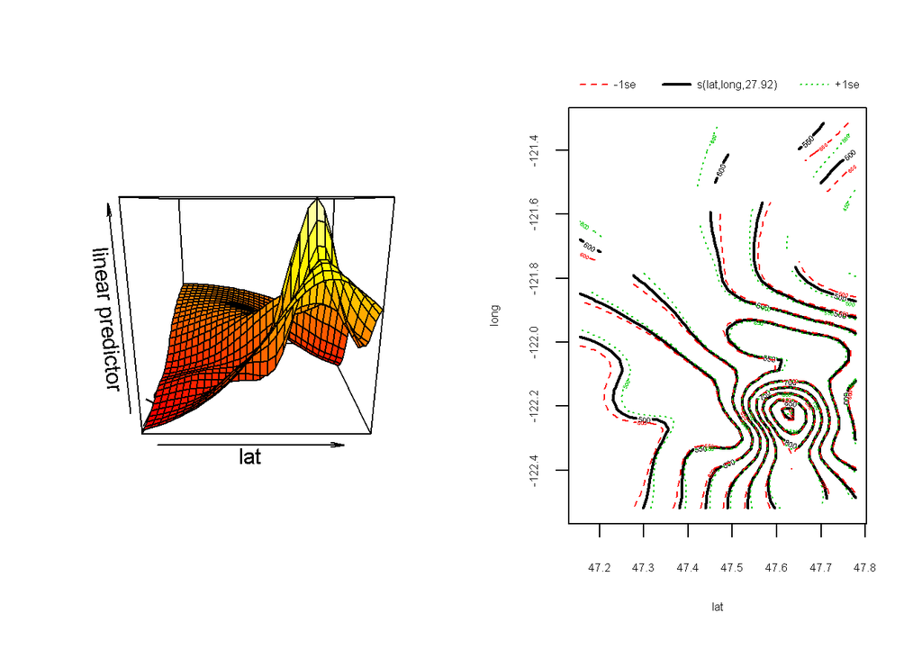

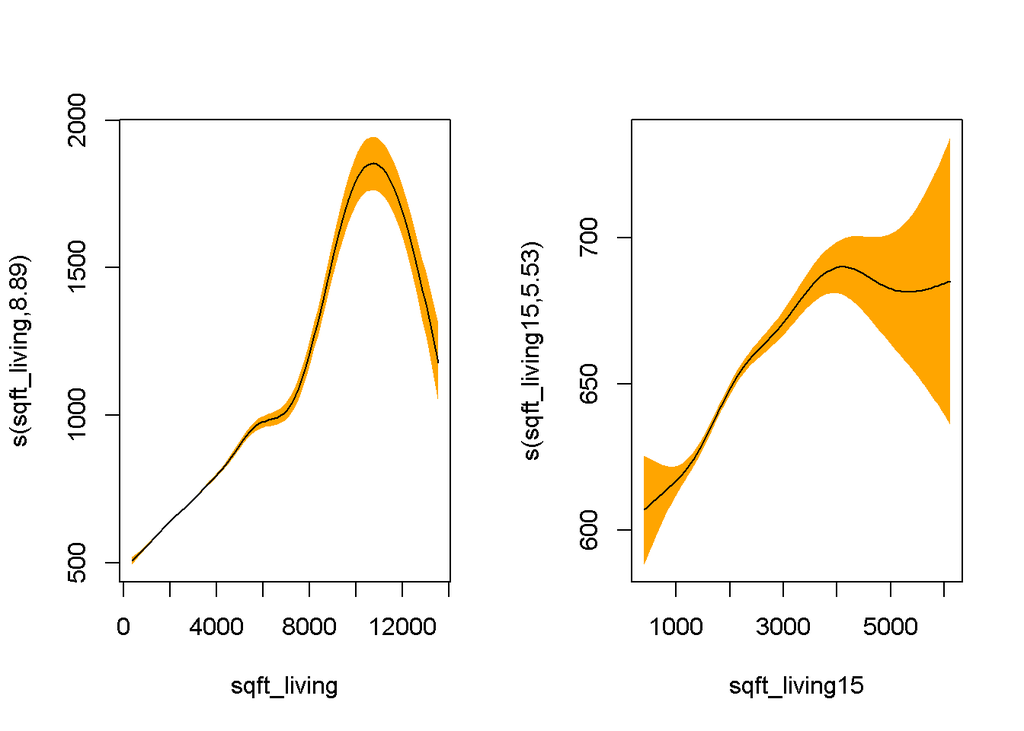

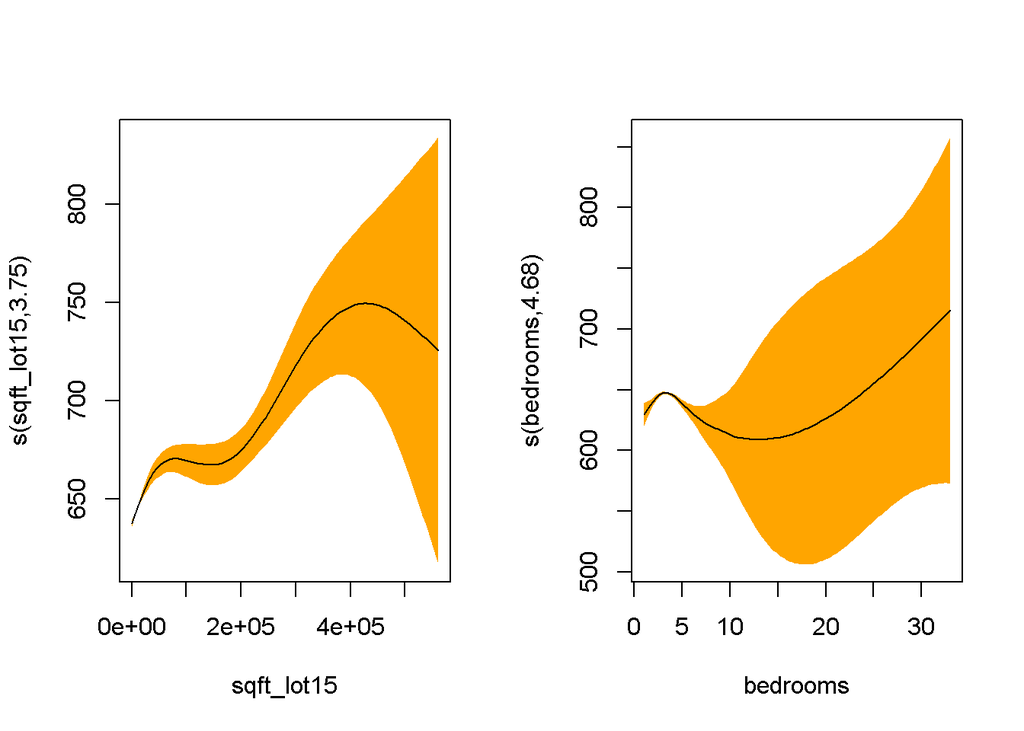

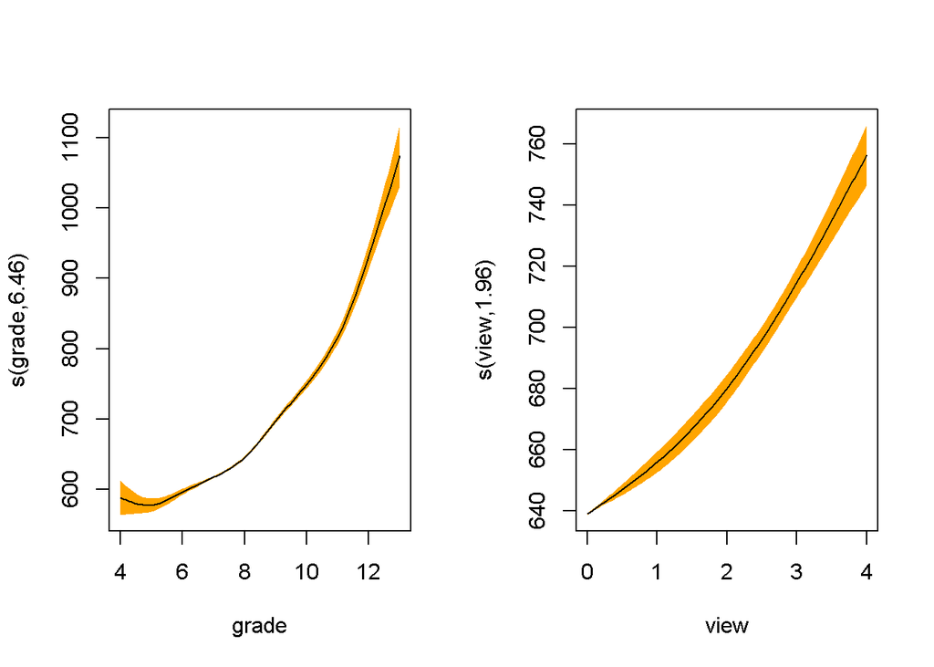

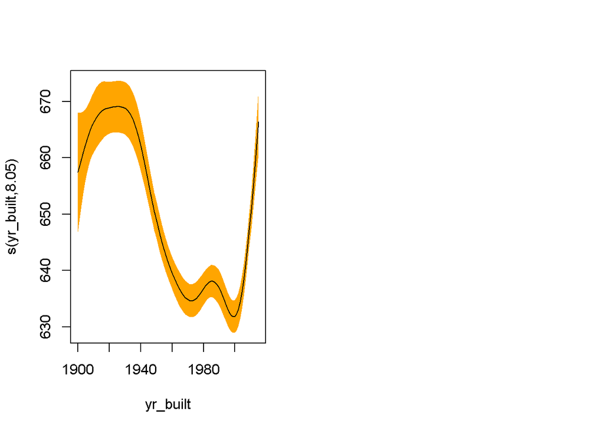

```r
layout(matrix(1:2, ncol = 2))
vis.gam (x=model_gam4,view=c("lat","long"),plot.type="persp")
plot(model_gam4, scale = 0,shade = TRUE, shade.col = "orange", shift=coef(model_gam4)[1])
```

## GAM FIT

Verificar un GAM fitted es como verificar un GLM fitted pero con dos diferencias fundamentales: 1.-Las dimensiones básicas utilizadas para los términos suaves deben verificarse 2.-En segundo lugar, supuestos de distribución GLM regular, los GAM pueden ser más sensibles. Por ello se usa un gráfico QQ residual mejorado.

Esta función representa 4 gráficos de diagnóstico estándar

1.-The test of whether the basis dimension for a smooth is adequate. Ver si el nivel de Smooth es el adecuado. Los valores p bajos pueden indicar que la dimensión base, k, se ha establecido demasiado baja, especialmente si el EDF informado está cerca de k ‘, el FED máximo posible para el término. Duplicar a un ’k’ sospechoso y volver a ajustarlo es una buena prueba 2.-QQ Gam 3.-Distribución de la varianza de los errores 4.-Response vs Fitted Value.

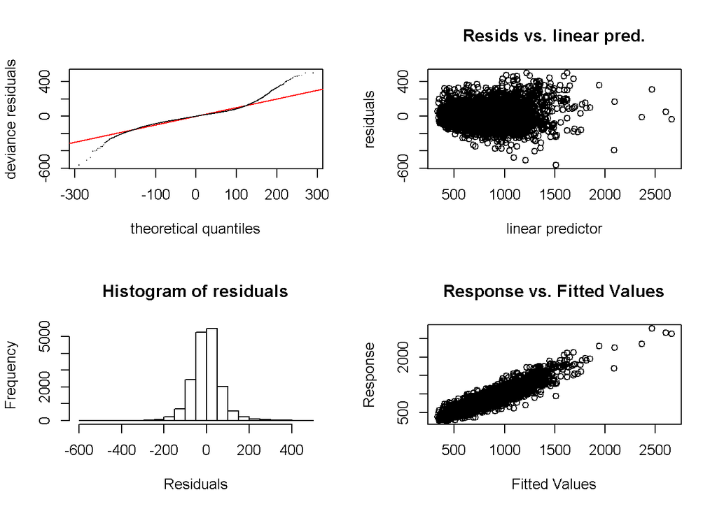

```
##
## Method: REML   Optimizer: outer newton
## full convergence after 11 iterations.
## Gradient range [-0.001383585,0.001347385]
## (score 98570.73 & scale 5194.973).
## Hessian positive definite, eigenvalue range [0.4619032,8634.026].
## Model rank =  80 / 80
##
## Basis dimension (k) checking results. Low p-value (k-index<1) may
## indicate that k is too low, especially if edf is close to k'.
##
##                     k'   edf k-index p-value
## s(lat,long)      28.00 27.92    0.73  <2e-16 ***
## s(sqft_living)    9.00  8.89    0.97   0.005 **
## s(sqft_living15)  9.00  5.53    1.01   0.755
## s(sqft_lot15)     4.00  3.75    0.97   0.020 *
## s(bedrooms)       9.00  4.68    0.98   0.105
## s(grade)          7.00  6.46    1.00   0.540
## s(view)           2.00  1.96    0.97   0.020 *
## s(yr_built)       9.00  8.05    1.00   0.430
## ---
## Signif. codes:  0 '***' 0.001 '**' 0.01 '*' 0.05 '.' 0.1 ' ' 1
```

```r
# Diagnóstico
gam.check(model_gam4)
```

### Relanzamos el modelo GAM Modificando los K Versión 5

```r
# Diagnóstico

model_gam5 <- gam (sqrt(price)~ s(lat,long,k=20) +s(sqft_living,k=8)  +s(sqft_living15) + s(sqft_lot15,k=3) + s(bedrooms)  + s(grade,k=6)   + waterfront + condition + s(view,k=3) + s(yr_built,k=8) , data=train, method="REML")

summary(model_gam5)
```

```
##
## Family: gaussian
## Link function: identity
##
## Formula:
## sqrt(price) ~ s(lat, long, k = 20) + s(sqft_living, k = 8) +
##     s(sqft_living15) + s(sqft_lot15, k = 3) + s(bedrooms) + s(grade,
##     k = 6) + waterfront + condition + s(view, k = 3) + s(yr_built,
##     k = 8)
##
## Parametric coefficients:
##             Estimate Std. Error t value Pr(>|t|)
## (Intercept)  634.501      3.527  179.88   <2e-16 ***
## waterfront   239.430      8.172   29.30   <2e-16 ***
## condition     20.624      1.020   20.22   <2e-16 ***
## ---
## Signif. codes:  0 '***' 0.001 '**' 0.01 '*' 0.05 '.' 0.1 ' ' 1
##
## Approximate significance of smooth terms:
##                     edf Ref.df       F  p-value
## s(lat,long)      18.942 19.000 995.233  < 2e-16 ***
## s(sqft_living)    6.928  6.997 544.614  < 2e-16 ***
## s(sqft_living15)  6.214  7.336  72.662  < 2e-16 ***
## s(sqft_lot15)     1.952  1.998  51.784  < 2e-16 ***
## s(bedrooms)       4.685  5.552   7.508 1.73e-07 ***
## s(grade)          4.810  4.980 486.229  < 2e-16 ***
## s(view)           1.936  1.996 330.022  < 2e-16 ***
## s(yr_built)       6.600  6.937  36.668  < 2e-16 ***
## ---
## Signif. codes:  0 '***' 0.001 '**' 0.01 '*' 0.05 '.' 0.1 ' ' 1
##
## R-sq.(adj) =  0.855   Deviance explained = 85.5%
## -REML =  99719  Scale est. = 5963.7    n = 17280
```

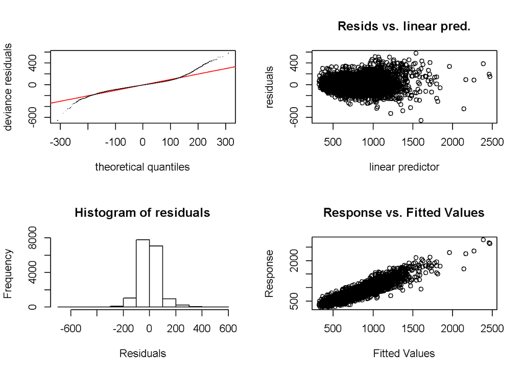

```
##
## Method: REML   Optimizer: outer newton
## full convergence after 16 iterations.
## Gradient range [-0.001446952,0.0009637241]
## (score 99719.45 & scale 5963.672).
## Hessian positive definite, eigenvalue range [0.4380358,8634.013].
## Model rank =  63 / 63
##
## Basis dimension (k) checking results. Low p-value (k-index<1) may
## indicate that k is too low, especially if edf is close to k'.
##
##                     k'   edf k-index p-value
## s(lat,long)      19.00 18.94    0.67  <2e-16 ***
## s(sqft_living)    7.00  6.93    0.97    0.03 *
## s(sqft_living15)  9.00  6.21    1.00    0.46
## s(sqft_lot15)     2.00  1.95    0.99    0.14
## s(bedrooms)       9.00  4.68    1.02    0.86
## s(grade)          5.00  4.81    1.03    0.96
## s(view)           2.00  1.94    1.00    0.57
## s(yr_built)       7.00  6.60    1.03    0.99
## ---
## Signif. codes:  0 '***' 0.001 '**' 0.01 '*' 0.05 '.' 0.1 ' ' 1
```

```r
# Diagnóstico
gam.check(model_gam5)
```

### Comparamos RME modelo GAM1 modelo GAM5

```r
pred.modelo.gam1 <-  predict(model_gam, control)
new1=sqrt(control$price)
test.error.gam1 <- mean((pred.modelo.gam1 - new1)^2)

pred.modelo.gam2 <-  predict(model_gam2, control)
new2=sqrt(control$price)
test.error.gam2 <- mean((pred.modelo.gam2 - new2)^2)

pred.modelo.gam3 <-  predict(model_gam3, control)
new3=sqrt(control$price)
test.error.gam3 <- mean((pred.modelo.gam3 - new3)^2)

pred.modelo.gam4 <-  predict(model_gam4, control)
new4=sqrt(control$price)
test.error.gam4 <- mean((pred.modelo.gam4 - new4)^2)


pred.modelo.gam <-  predict(model_gam5, control)
new5=sqrt(control$price)
test.error.gam5 <- mean((pred.modelo.gam - new5)^2)
test.error.gam5
```

```
## [1] 5718.564
```

### Representación Gráfica de estos RME

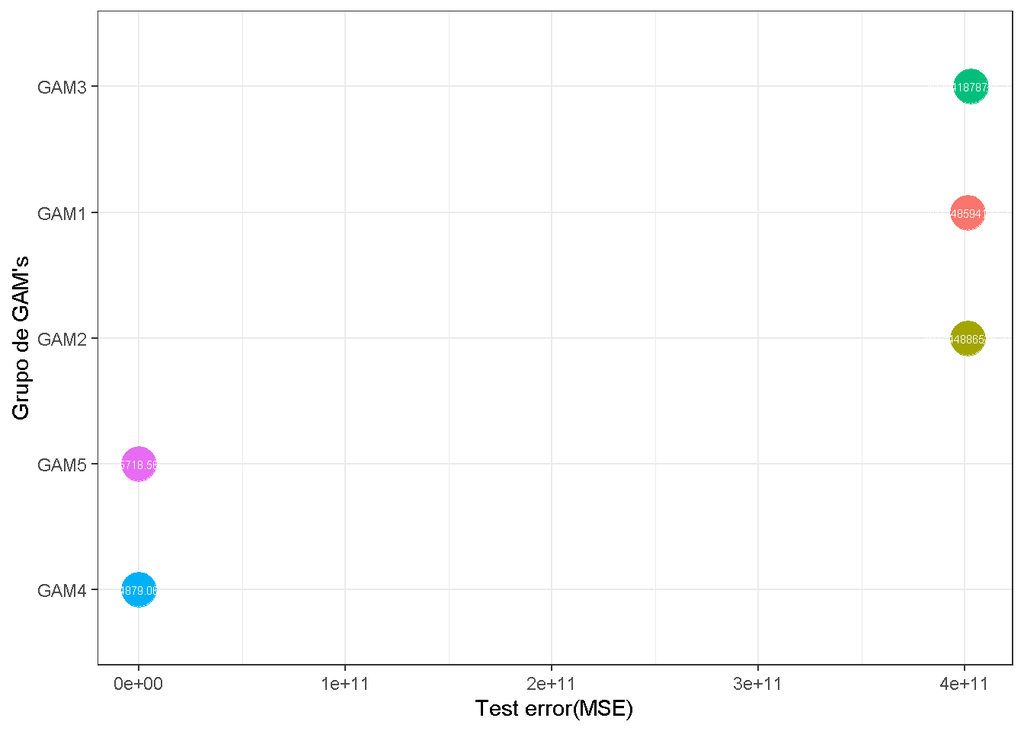

```r
modelo <- c("GAM1", "GAM2",  "GAM3",  "GAM4", "GAM5")
test.MSE <- c(test.error.gam1,test.error.gam2,test.error.gam3,test.error.gam4, test.error.gam5)

comparacion <- data.frame(modelo = modelo, test.MSE = test.MSE)

ggplot(data = comparacion, aes(x = reorder(x = modelo, X = test.MSE),
                               y = test.MSE, color = modelo,
                               label = round(test.MSE,2))) +
geom_point(size = 8) +
geom_text(color = "white", size = 2) +
labs(x = "Grupo de GAM's", y = "Test error(MSE)") + theme_bw() +
coord_flip() + theme(legend.position = "none")
```

### cáculo del R2 Modelo 4 para la poblacion Train

```r
summary(model_gam4)$r.sq
```

```
## [1] 0.873639
```

### cáculo del R2 Modelo 4 para la poblacion Control

```r
SST <- mean((new4 - mean(new4))^2)
SSE <- test.error.gam4
R2 <- 1 - SSE / SST
R2
```

```
## [1] 0.8833939
```

### cáculo del R2 Modelo 5 para la poblacion Train

```r
summary(model_gam5)$r.sq
```

```
## [1] 0.8549414
```

### cáculo del R2 Modelo 5 para la poblacion Control

```r
SST <- mean((new5 - mean(new5))^2)
SSE <- test.error.gam5
R2 <- 1 - SSE / SST
R2
```

```
## [1] 0.8633304
```

```r
anova(model_gam, model_gam2,model_gam2,model_gam3,model_gam4,model_gam5, test="Chisq")
```

```
## Analysis of Deviance Table
##
## Model 1: price ~ s(lat, long) + s(sqft_living) + s(sqft_living15) + s(sqft_lot15) +
##     s(bedrooms) + s(bathrooms) + s(grade) + waterfront + s(condition,
##     k = 3) + s(view, k = 3) + s(yr_built)
## Model 2: price ~ s(lat, long) + s(sqft_living) + s(sqft_living15) + s(sqft_lot15) +
##     s(bedrooms) + s(bathrooms) + s(grade) + waterfront + condition +
##     s(view, k = 3) + s(yr_built)
## Model 3: price ~ s(lat, long) + s(sqft_living) + s(sqft_living15) + s(sqft_lot15) +
##     s(bedrooms) + s(bathrooms) + s(grade) + waterfront + condition +
##     s(view, k = 3) + s(yr_built)
## Model 4: price ~ s(lat, long) + s(sqft_living) + s(sqft_living15) + s(sqft_lot15) +
##     s(bedrooms) + s(grade) + waterfront + condition + s(view,
##     k = 3) + s(yr_built)
##   Resid. Df Resid. Dev       Df    Deviance Pr(>Chi)
## 1     17184 3.7377e+14
## 2     17185 3.7377e+14 -0.76372 -1.2861e+09   0.7089
## 3     17185 3.7377e+14  0.00000  0.0000e+00
## 4     17195 3.8139e+14 -9.47070 -7.6205e+12   <2e-16 ***
## ---
## Signif. codes:  0 '***' 0.001 '**' 0.01 '*' 0.05 '.' 0.1 ' ' 1
```

```r
AIC(model_gam,model_gam2,model_gam3,model_gam4,model_gam5)
```

```
##                  df      AIC
## model_gam  92.99368 460442.9
## model_gam2 92.28984 460441.5
## model_gam3 82.72151 460771.1
## model_gam4 73.64285 196953.5
## model_gam5 57.89458 199321.8
```